# La régionalisation du Monde

## … qui sont objet de débats politique…

- “la Turquie *n’est pas un pays européen* Pourquoi ? Parce que sa capitale n’est pas en Europe, parce que “95% de sa population vit en dehors de l’Europe. […] Le lendemain de l’ouverture des négociations avec la Turquie, vous aurez une demande marocaine d’adhésion à l’UE, le Roi du Maroc le dit depuis longtemps […]. Si nous devons laisser le continent ouvert au sud-est, pourquoi ne pas le laisser ouvert au sud-ouest ?”

Source : **Valery Giscard d’Estaing**, Président de la convention sur l’avenir de l’Union Européenne, 2002

#### Caricature de Plantu, Le Monde, 2002

[figure not shown]

## … et de perceptions variables.

- “les frontières ne sont pas données par la nature, mais sont des productions culturelles. Etablies dans des contextes historiques spécifiques et pour servir des projets particuliers, ces frontières sont sujettes à des changements et doivent toujours être remises en question.”

Source : **P. Clerc**, 2002, Turquie : la géographie-prétexte [Le Monde](https://www.lemonde.fr/europe/article/2002/11/18/turquie-la-geographie-pretexte-par-pascal-clerc_298538_3214.html)

#### Limites de l’Europe tracé par des étudiants français en 2021

[figure not shown]

## Continents “durs” et continents “mous”

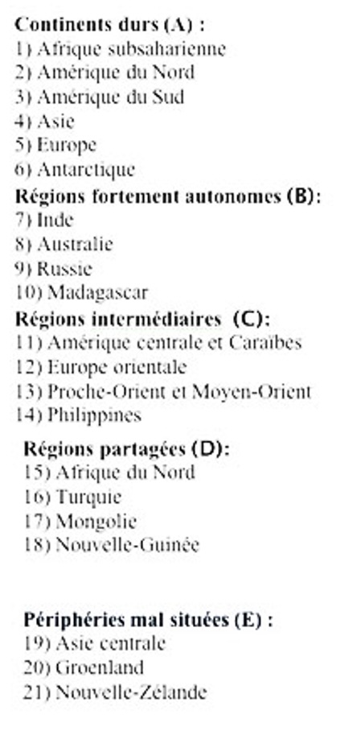

[figure not shown]

Source : **Grataloup, Christian, 2009,** *L’invention des continents: comment l’Europe a découpé le monde*. Larousse, Paris

# DECOUPAGE DU MONDE EN REGIONS HOMOGENES

## Qu’est-ce qu’une région homogène ?

- “La région peut se concevoir comme un découpage fondé sur la spatialisation d’un seul ensemble de caractères homogènes […]. On parle de domaine lorsque le climat et le relief constituent l’unique critère de différenciation régionale ou de milieu quand le géographe tient également compte du milieu vivant”

**Levy J. & Lussault M., 2003,** *Dictionnaire de la géographie et de l’espace des sociétés*, Belin, Paris.

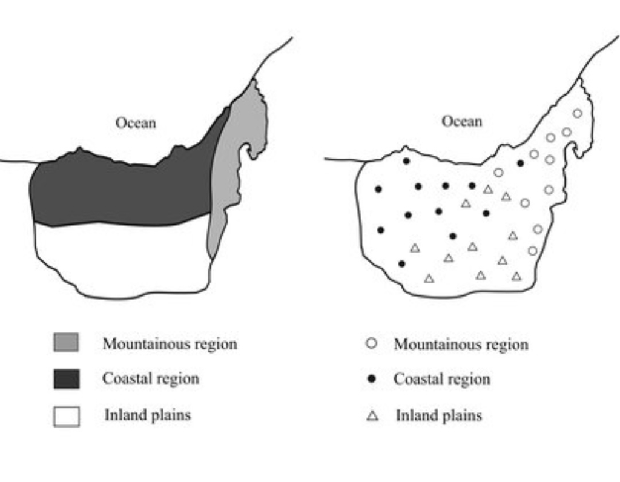

## Régions naturelles (1) : les “Royaumes” biogéographiques …

“The Kingdom, or Realm, is the highest-ranking unit in the biogeographical system. Each of these territories has continental dimensions and its biotas show a certain degree of common and specific characteristics of each one, although they usually encompass a great diversity of climates.”

Source : **Loidi, J., & Vynokurov, D. (2024).** The biogeographical kingdoms and regions of the world. *Mediterranean Botany, 45(2)*,

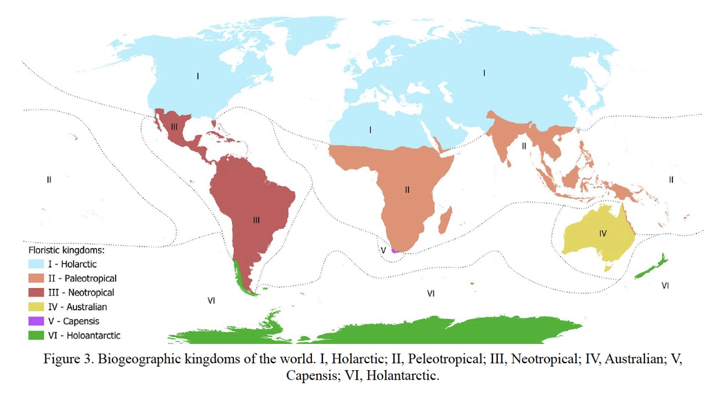

## … et leurs subdivisions en régions.

“The kingdoms are further divided into regions, which are extensive territories characterized by a high level of floristic specificity, which can include some small endemic families, and the level of endemism increases as we descend to lower taxonomic ranks such as genera and species, where it encompasses a majority of the taxa.”

Source : **Loidi, J., & Vynokurov, D. (2024).** The biogeographical kingdoms and regions of the world. *Mediterranean Botany, 45(2)*,

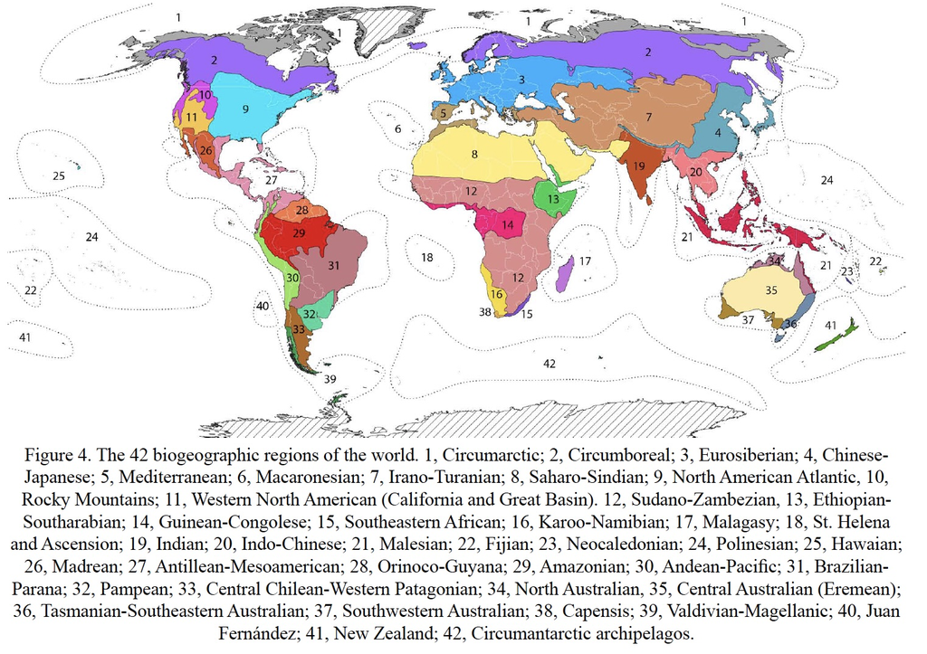

## Régions naturelles (2) : Les zones climatiques traditionnelles …

#### La théorie antique des climats

«Les hommes du Nord sont forts et valeureux, car endurcis par le climat froid, mais ils sont peu intelligents et inaptes aux affaires politiques ; les hommes du Sud (Nord-Africains, Asiatiques, Éthiopiens…) ont une intelligence vive et une grande imagination, mais ils sont mous car affaiblis par le climat chaud ; enfin, les hommes des moyennes latitudes possèdent les meilleures qualités des uns et des autres».

Source : **Pinna M., 1989,** “Un aperçu historique de «la théorie des climats»,” *Annales de géographie*, Vol. 98, No. 547

#### Carte scolaire contemporaine (CM1-CM2)

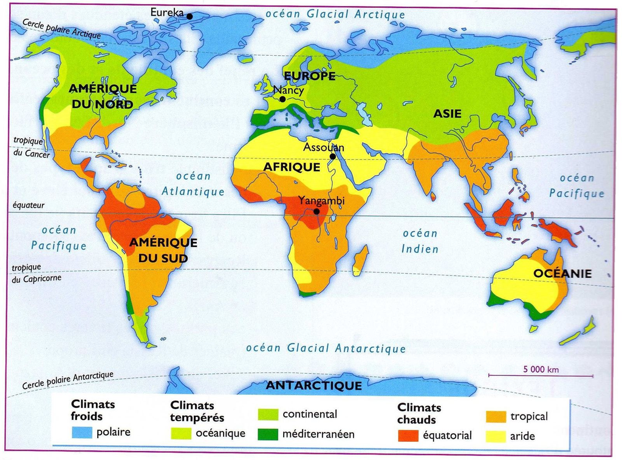

## … et le découpage régional du GIEC

“Plusieurs séries de régions de référence ont été utilisées dans la littérature pour la synthèse régionale des informations observées et modélisées sur le climat et le changement climatique. Un exemple courant est la série de régions de référence utilisée dans le rapport spécial du Groupe d’experts intergouvernemental sur l’évolution du climat (GIEC) sur la gestion des risques d’événements extrêmes et de catastrophes pour faire progresser l’adaptation au climat (SREX)”.

Source : [Iturbide & al., 2020](https://essd.copernicus.org/articles/12/2959/2020/)

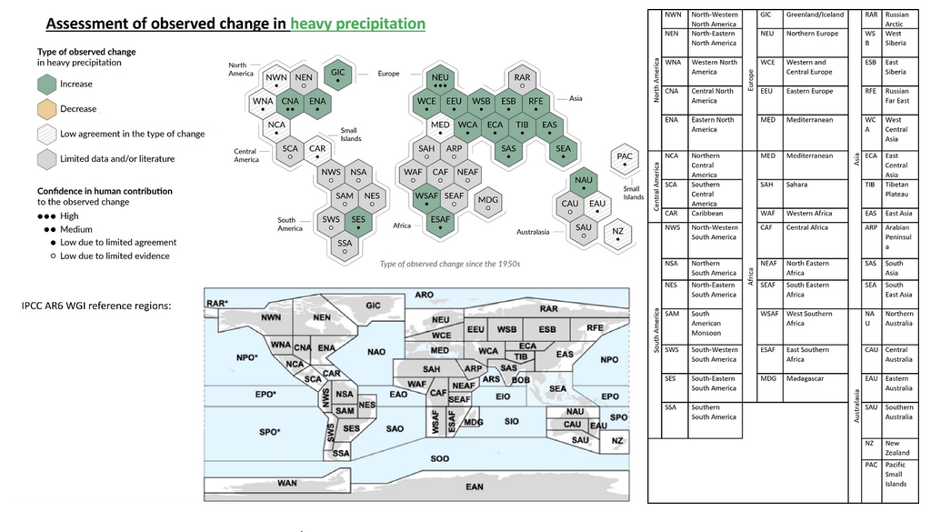

## Régions ‘culturelles’ (1) : Les races (France, 1937)

[figure not shown]

Source ; Carte publiée en France vers 1937 dans un manuel de géographie. **Remarquer le choix des couleurs utilisées”**

## Régions ‘culturelles’ (1) : Les races (URSS, 1970’s)

[figure not shown]

Source ; Carte des “races humaines” produite en Union soviétique dans les années 1960-70 et traduite en anglais. **Remarquer la catégorie “transinational”**

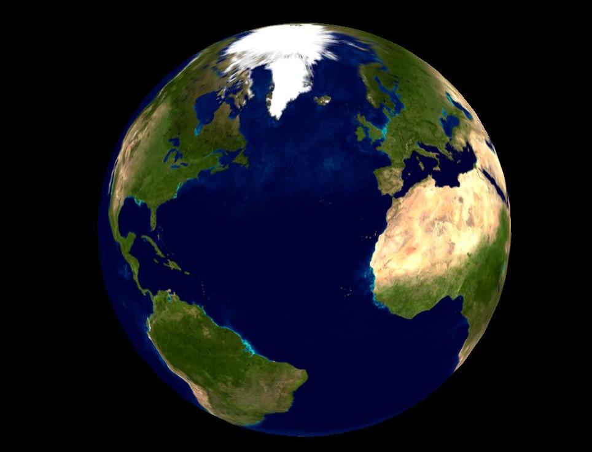